# Chapter 6 Taxonomic shares and dissimilarity contributions

The diversity and pairwise beta diversity chapters describe whole communities. Here we use `hilldiv3::hillshare()` to allocate each sample’s Hill **power sum** to sets of representative MAGs. A share is a fraction between zero and one, not a fraction of the effective Hill number reported by `hilldiv()`. The calculation is descriptive; it does not test whether a phylum is enriched in a habitat.

This chapter was rendered with `hilldiv3` version 3.2.0.

## 6.1 Define the genome sets

We use four phyla that have substantial abundance or dissimilarity contributions in the field–grassland soil comparison. The `Other` set contains every remaining representative, so the five sets are disjoint and exhaustive. Each representative stands for its published 95% ANI cluster; the shares describe those cluster profiles, not the abundance of every MAG within a cluster.

```r
phylum <- sub("^p__", "", genome_metadata$phylum)
focus_phyla <- c("Pseudomonadota", "Actinomycetota",
                  "Acidobacteriota", "Thermoproteota")
contrast_habitats <- c("Agricultural field soil", "Natural grassland soil")
share_sets <- lapply(focus_phyla, function(name) {
  genome_metadata$genome_id[phylum == name]
})
names(share_sets) <- focus_phyla
share_sets$Other <- genome_metadata$genome_id[!phylum %in% focus_phyla]
stopifnot(sum(lengths(share_sets)) == nrow(genome_metadata),
          setequal(unlist(share_sets, use.names = FALSE),
                   genome_metadata$genome_id))
```

`hillshare()` returns one row for each sample, order, diversity type, and set. The phylogenetic call uses the same representative tree as the earlier chapters. Both diversity types are requested together.

```r
shares <- hilldiv3::hillshare(
  overview_abundance, q = c(0, 1, 2), tree = genome_tree,
  type = c("neutral", "phylogenetic"), sets = share_sets
)
```

## 6.2 Shares across habitats

The heatmap shows the median share among the 45 samples in each habitat. Its colour scale is the same in every panel. At neutral $q=1$, a set’s share equals its summed relative abundance. At $q=0$, each detected representative has equal neutral weight; at $q=2$, abundant representatives carry more weight. Phylogenetic shares also allocate the weights of tree branches to their descendant representatives.

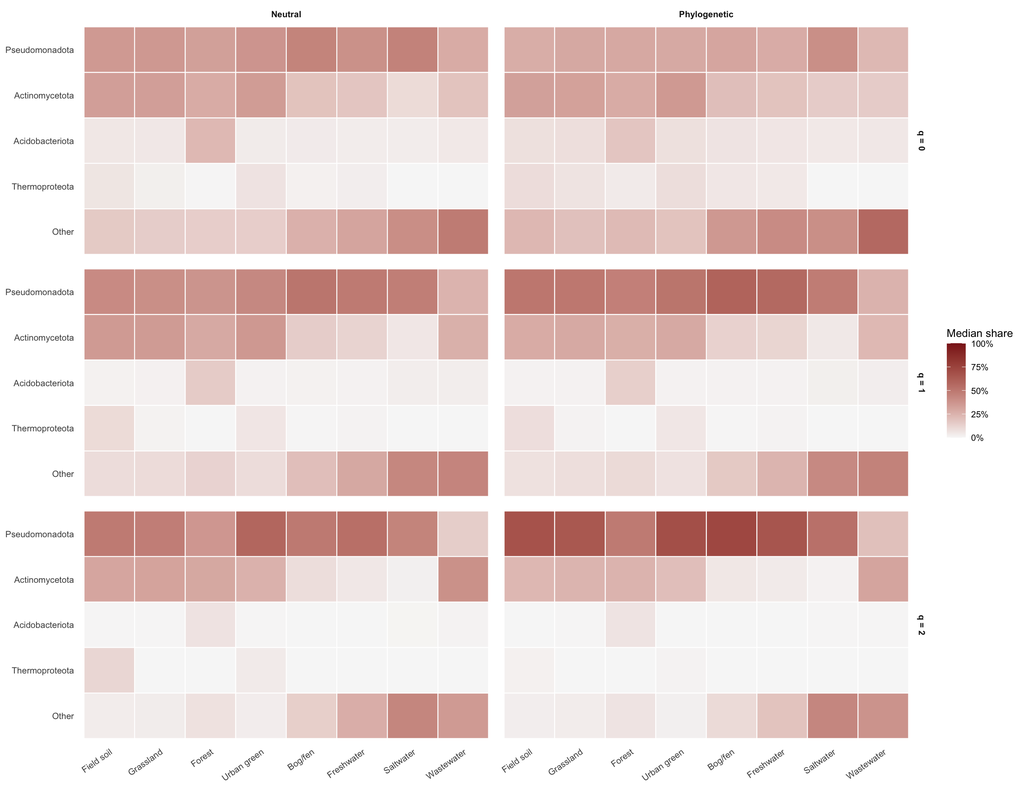

```r
ggplot2::ggplot(share_medians,
                ggplot2::aes(x = Habitat, y = Set, fill = share)) +
  ggplot2::geom_tile(colour = "white", linewidth = 0.4) +
  ggplot2::scale_fill_gradient(
    low = "#f7f7f7", high = "#8b1e1e", limits = c(0, 1),
    labels = function(x) sprintf("%.0f%%", 100 * x), name = "Median share"
  ) +
  ggplot2::facet_grid(Order ~ Type) +
  ggplot2::labs(x = NULL, y = NULL) +
  ggplot2::theme_minimal(base_size = 10) +
  ggplot2::theme(
    panel.grid = ggplot2::element_blank(),
    axis.text.x = ggplot2::element_text(angle = 35, hjust = 1),
    strip.text = ggplot2::element_text(face = "bold")
  )
```

*Median power-sum shares in each habitat. Medians are taken separately for each set, so the displayed medians need not sum to one; the five shares sum to one within every individual sample, type, and order.*

## 6.3 A stable phylum total hides order turnover

The broad habitat comparison in the [Microflora Danica atlas](https://doi.org/10.1038/s41586-025-09794-2) places fields and grasslands among similar soil environments. Its [supplementary genome analysis](https://media.springernature.com/original/springer-static/esm/art%3A10.1038%2Fs41586-025-09794-2/MediaObjects/41586_2025_9794_MOESM1_ESM.pdf) notes widespread *Gaiella* and a *Trebonia* species found in grasslands. We use the representative MAG profiles to ask whether similar abundance at the phylum level can conceal opposing changes among its members.

For Actinomycetota, we define separate sets for Gaiellales and Streptosporangiales. These sets are disjoint; `Other` completes the partition. The parent phylum’s share comes from the earlier `hillshare()` result. At neutral $q=1$, each share equals that set’s summed abundance within the MFD MAG profile. The order names are taxonomic assignments, not functional annotations.

```r
actino_order_shares <- hilldiv3::hillshare(
  overview_abundance[, soil_samples, drop = FALSE],
  q = 1, type = "neutral", sets = actino_order_sets
)
```

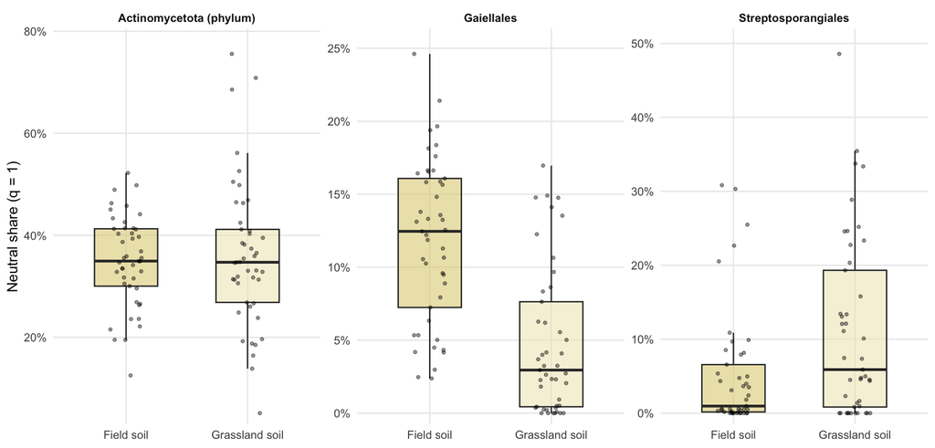

```r
ggplot2::ggplot(actino_plot_data,
                ggplot2::aes(x = Habitat, y = share, fill = Habitat)) +
  ggplot2::geom_boxplot(outlier.shape = NA, width = 0.52,
                        alpha = 0.55) +
  ggplot2::geom_point(
    position = ggplot2::position_jitter(width = 0.13, height = 0,
                                        seed = 42),
    size = 0.9, alpha = 0.4
  ) +
  ggplot2::scale_fill_manual(values = c(
    "Field soil" = unname(phylum_colours["Actinomycetota"]),
    "Grassland soil" = "#EFE7BC"
  )) +
  ggplot2::scale_y_continuous(
    labels = function(x) sprintf("%.0f%%", 100 * x),
    expand = ggplot2::expansion(mult = c(0.03, 0.07))
  ) +
  ggplot2::facet_wrap(~ Taxon, nrow = 1, scales = "free_y") +
  ggplot2::labs(x = NULL, y = "Neutral share (q = 1)") +
  ggplot2::theme_minimal(base_size = 11) +
  ggplot2::theme(
    legend.position = "none",
    panel.grid.minor = ggplot2::element_blank(),
    strip.text = ggplot2::element_text(face = "bold")
  )
```

*Each point is one sample; boxes show medians and interquartile ranges. The percentage scale differs between taxon panels. Shares are relative to the detected MFD MAG profile, not to all DNA in a sample.*

The median Actinomycetota share is 34.9% in fields and 34.7% in grasslands. Within that nearly stable total, Gaiellales is 12.5% versus 3.0%, while Streptosporangiales is 1.0% versus 5.9%. The order distributions overlap, but their directions also appear when we restrict the panel to the two sampling projects containing both habitats (16 field and 7 grassland samples): the Gaiellales means are 12.3% and 4.1%, and the Streptosporangiales means are 8.7% and 18.3%, respectively. This subset is small and does not establish independence from sampling context. The pattern is a within-phylum compositional contrast, not a claim about the orders’ ecological functions.

## 6.4 A contrasting phylum-level signal

Thermoproteota has a higher $q=1$ share in field soil than in grassland soil. The next figure shows the sample-level values for both diversity types rather than only the habitat medians in the heatmap.

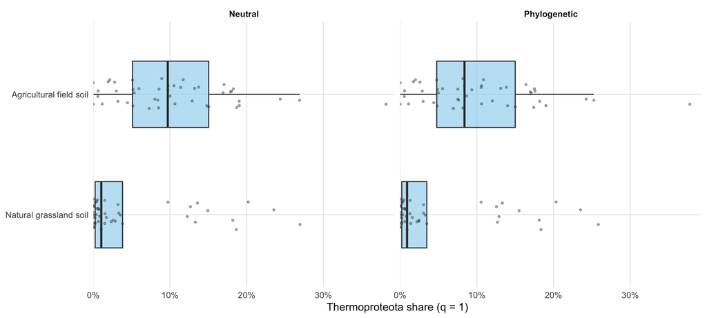

```r
ggplot2::ggplot(thermoproteota,
                ggplot2::aes(x = share, y = habitat)) +
  ggplot2::geom_boxplot(outlier.shape = NA, width = 0.55,
                        fill = phylum_colours[["Thermoproteota"]], alpha = 0.55,
                        colour = "grey20") +
  ggplot2::geom_jitter(height = 0.13, width = 0, alpha = 0.4,
                       size = 0.8, colour = "grey25") +
  ggplot2::facet_wrap(~ Type, nrow = 1) +
  ggplot2::scale_x_continuous(
    labels = function(x) sprintf("%.0f%%", 100 * x),
    breaks = seq(0, 0.4, by = 0.1),
    expand = ggplot2::expansion(mult = c(0, 0.03))
  ) +
  ggplot2::labs(x = "Thermoproteota share (q = 1)", y = NULL) +
  ggplot2::theme_minimal(base_size = 11) +
  ggplot2::theme(panel.grid.minor = ggplot2::element_blank(),
                 strip.text = ggplot2::element_text(face = "bold"))
```

*Each point is one sample; boxes show medians and interquartile ranges. The panels share an abundance scale. A zero means no representative from this phylum was detected in that sample.*

The median neutral Thermoproteota share is 9.7% in field soil and 1.0% in grassland soil. The distributions overlap, and these unpaired samples do not establish a land-use effect.

## 6.5 How order and tree weighting change a share

For Pseudomonadota, the next plot compares sample medians and interquartile ranges across orders in four soil habitats. The lines connect summaries, not individual samples. A shared vertical scale makes both diversity types directly visible.

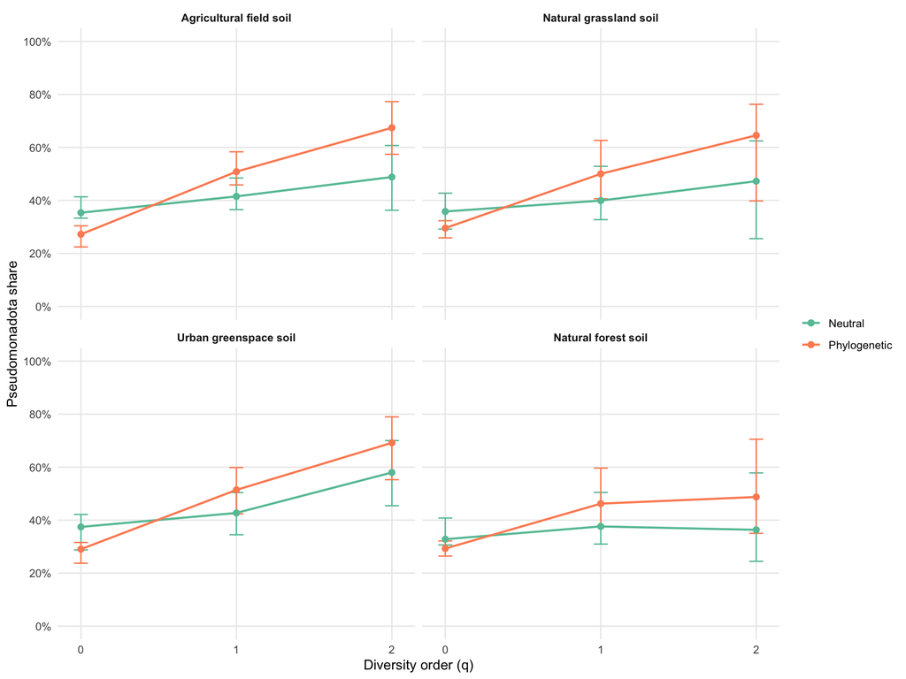

```r
ggplot2::ggplot(share_order,
                ggplot2::aes(x = q, y = median, colour = Type, group = Type)) +
  ggplot2::geom_errorbar(ggplot2::aes(ymin = lower, ymax = upper),
                         width = 0.09, linewidth = 0.5) +
  ggplot2::geom_line(linewidth = 0.8) +
  ggplot2::geom_point(size = 2) +
  ggplot2::scale_x_continuous(breaks = c(0, 1, 2)) +
  ggplot2::scale_y_continuous(
    limits = c(0, 1), breaks = seq(0, 1, by = 0.2),
    labels = function(x) sprintf("%.0f%%", 100 * x)
  ) +
  ggplot2::scale_colour_manual(values = type_colours) +
  ggplot2::facet_wrap(~ habitat, ncol = 2) +
  ggplot2::labs(x = "Diversity order (q)", y = "Pseudomonadota share",
                colour = NULL) +
  ggplot2::theme_minimal(base_size = 11) +
  ggplot2::theme(panel.grid.minor = ggplot2::element_blank(),
                 strip.text = ggplot2::element_text(face = "bold"))
```

*Points are medians across 45 samples; bars are interquartile ranges. They describe the selected panel and are not confidence intervals.*

The phylogenetic tree is rooted but not ultrametric. At $q=1$, differences between neutral and phylogenetic shares reflect root-to-tip path lengths in addition to abundance. At other orders, shared branch weights also affect the allocation. The panel has no matched functional-distance matrix, so we restrict this example to neutral and phylogenetic shares. Habitat and sampling year are partly confounded; these figures do not establish a habitat effect.

## 6.6 Which phyla account for dissimilarity?

We compare the **mean abundance profiles** of agricultural field soil and natural grassland soil, calculated earlier from 45 samples per habitat. Both are soils, but the source metadata classify one as agricultural and the other as natural. This gives the contribution analysis an ecological land-use question with a shared sample matrix. It is one comparison of two habitat mean vectors, not the median of the 2,025 individual sample pairs shown in the pairwise analysis. The samples are not matched on soil properties, vegetation, location, or sampling year, so this descriptive contrast cannot isolate an effect of human land use.

The same five disjoint genome sets used for `hillshare()` cover every representative. Here `hillcontrib()` attributes the $q=1$ C dissimilarity to those sets. A contribution is a part of the dissimilarity, whereas the earlier power-sum share describes one profile on its own.

```r
contrib_neutral <- hilldiv3::hillcontrib(
  contrast_profiles, q = 1, metric = "C", type = "neutral",
  sets = share_sets
)
contrib_phylogenetic <- hilldiv3::hillcontrib(
  contrast_profiles, q = 1, metric = "C", tree = genome_tree,
  type = "phylogenetic", sets = share_sets
)
```

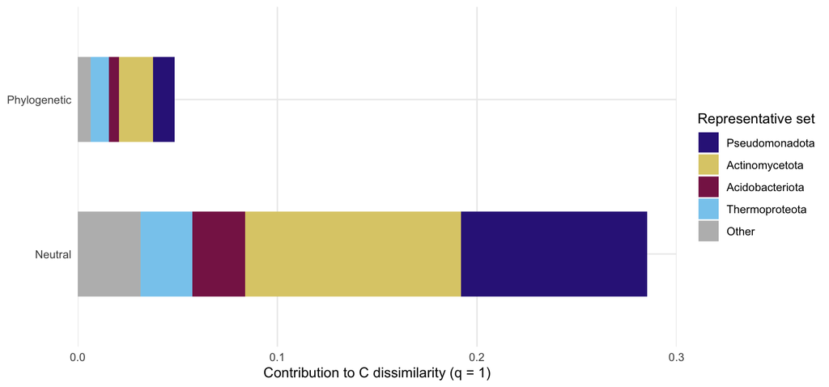

```r
ggplot2::ggplot(contributions,
                ggplot2::aes(x = Type, y = contribution, fill = set)) +
  ggplot2::geom_col(width = 0.55) +
  ggplot2::coord_flip() +
  ggplot2::scale_y_continuous(
    limits = c(0, 0.3), breaks = seq(0, 0.3, by = 0.1),
    expand = ggplot2::expansion(mult = c(0, 0))
  ) +
  ggplot2::scale_fill_manual(values = phylum_colours) +
  ggplot2::labs(x = NULL, y = "Contribution to C dissimilarity (q = 1)",
                fill = "Representative set") +
  ggplot2::theme_minimal(base_size = 11) +
  ggplot2::theme(panel.grid.minor = ggplot2::element_blank())
```

*The bar lengths are the C dissimilarities for the same two mean profiles; their segments sum to those values. They are not median contributions among sample pairs.*

Neutral C dissimilarity is 0.285 and phylogenetic C dissimilarity is 0.048. Actinomycetota accounts for 37.9% of the neutral value and 35.3% of the phylogenetic value. Pseudomonadota and Thermoproteota also make substantial contributions. Phylogenetic attribution allocates shared branch turnover to descendant representatives under `hillcontrib()`’s specified rule; it is not a unique biological assignment of each branch to a phylum.

### 6.6.1 The orders behind the Actinomycetota contribution

The phylum totals above do not show which Actinomycetota representatives create the difference. We now partition the same two habitat mean profiles into Gaiellales, Streptosporangiales, the remaining Actinomycetota, and all representatives outside the phylum. The four sets are disjoint and exhaustive, so their C contributions sum to the corresponding whole-community values.

```r
actino_contrib_neutral <- hilldiv3::hillcontrib(
  contrast_profiles, q = 1, metric = "C", type = "neutral",
  sets = actino_contrib_sets
)
actino_contrib_phylogenetic <- hilldiv3::hillcontrib(
  contrast_profiles, q = 1, metric = "C", tree = genome_tree,
  type = "phylogenetic", sets = actino_contrib_sets
)
```

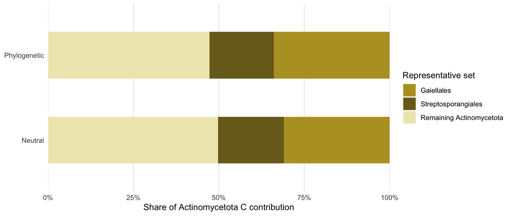

```r
ggplot2::ggplot(actino_contrib_plot,
                ggplot2::aes(x = Type, y = Fraction, fill = Set)) +
  ggplot2::geom_col(width = 0.55) +
  ggplot2::coord_flip() +
  ggplot2::scale_y_continuous(
    limits = c(0, 1), breaks = seq(0, 1, by = 0.25),
    labels = function(x) sprintf("%.0f%%", 100 * x),
    expand = ggplot2::expansion(mult = c(0, 0))
  ) +
  ggplot2::scale_fill_manual(values = c(
    Gaiellales = "#B79F2B", Streptosporangiales = "#7A6A1F",
    `Remaining Actinomycetota` = "#EFE7BC"
  )) +
  ggplot2::labs(x = NULL, y = "Share of Actinomycetota C contribution",
                fill = "Representative set") +
  ggplot2::theme_minimal(base_size = 11) +
  ggplot2::theme(panel.grid.minor = ggplot2::element_blank())
```

*The bars divide the Actinomycetota segment of the preceding figure, not the whole-community C value. Both use the same field and grassland mean profiles; these are not sample-pair medians.*

Gaiellales and Streptosporangiales together account for 50.2% of Actinomycetota’s neutral contribution and 52.8% of its phylogenetic contribution. Relative to the full C values, these two orders account for 19.1% and 18.6%, respectively. Thus the nearly unchanged phylum abundance does not imply that its constituent representatives are unchanged. The field and grassland samples differ in location, soil properties, sampling project, and year; these descriptive differences cannot be assigned to land management alone.

### 6.6.2 How phylogenetic weighting redistributes contributions

Thermoproteota accounts for 9.1% of the neutral C value and 19.0% of the phylogenetic value. Pseudomonadota moves in the opposite direction, from 32.7% to 22.0% of the phylogenetic value. Representatives assigned to Nitrososphaerales make up 100.0% and 99.7% of Thermoproteota abundance in the field and grassland mean profiles, respectively. That is a taxonomic assignment, not a measurement of function. The contribution shares describe two different C values; no significance test is involved. The figure shows one small clade from each phylum on the same branch-gap colour scale. The nonlinear colour mapping keeps smaller nonzero gaps visible; the legend reports the original gap values.

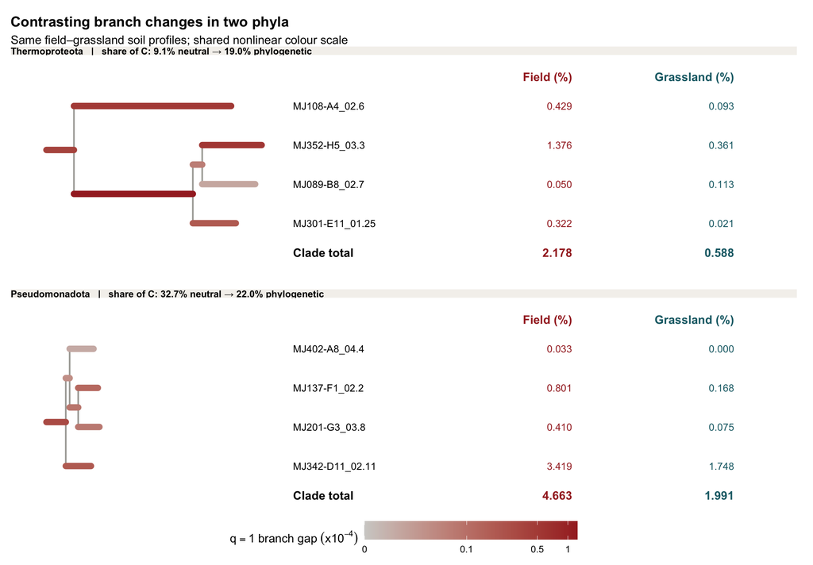

*Each panel shows a separate four-MAG clade in the source tree. Horizontal branches are drawn to scale and coloured by the same length-weighted $q=1$ abundance-gap scale, with nonlinear colour spacing; grey vertical lines connect them. All four Thermoproteota representatives shown are assigned to Nitrososphaerales, and their clade has a larger combined branch gap than the selected Pseudomonadota clade. The shares in the panel headings come from all representatives and branches in each phylum; these selected clades illustrate the contrast but do not alone determine the phylum-wide percentages.*